# Week 2: Frameworks, Benchmarks, and Literature Reviews

Ziyuan Huang

March 23, 2026

# Introduction

This week we move from a broad research idea to a structured, justifiable research plan. Good research is always **contextualized within the history of what has been done** — you must show that you understand the existing landscape before you can make a meaningful contribution to it. To do this, we focus on three foundational skills:

- A **Framework** is the intellectual structure for your study — an existing analytic, theoretical, or methodological tradition that guides how you approach your problem and interpret your results.
- A **Benchmark** is your yardstick for success — an established standard from prior work that lets you answer the question *“How good are my results compared to the best that’s been done?”*
- A **Literature Review** is the written argument that ties it all together — connecting existing research to your specific problem, establishing the importance of your research questions, and justifying your approach.

# Part 1: Frameworks

## What is a Framework?

For different types of problems, **frameworks** exist for the best — or at least most common — approaches to that class of problem. A framework is not something you invent; it is something you adopt, adapt, and justify. Your choice signals to readers that you understand the research tradition your work belongs to.

## Types of Frameworks

Research frameworks fall into three broad categories, and a single study may incorporate more than one:

[interactive chart not shown]

### Analytic Frameworks

Analytic frameworks define the *type of analysis* you will conduct and the computational or statistical tools best suited for that analysis.

| Framework | Description | Example Use Case |
| --- | --- | --- |
| Predictive Modeling | Build a model to estimate an unknown outcome from known inputs | Predicting student dropout from engagement data |
| Forecasting | Estimate future values of a time-series variable | Projecting enrollment trends over the next 5 years |
| Classification | Assign observations to discrete categories | Diagnosing disease from medical imaging |
| Clustering / Segmentation | Discover natural groupings in unlabeled data | Identifying patient risk profiles |

### Theoretical Frameworks

Theoretical frameworks provide the *conceptual lens* through which you interpret your problem and results. They connect your study to a body of scholarly thought.

| Framework | Description | Example Use Case |
| --- | --- | --- |
| Game Theory | Models strategic decision-making among rational agents | Analyzing competitive pricing behavior |
| Information Theory | Quantifies information, uncertainty, and communication limits | Measuring entropy in communication networks |
| Tinto’s Model | Explains student persistence through academic and social integration | Predicting college dropout |
| Technology Acceptance Model | Explains user adoption of new technologies | Studying e-learning platform adoption |

### Methodological Frameworks

Methodological frameworks define the *overall research design strategy* — how you will collect, generate, or analyze evidence.

| Framework | Description | Example Use Case |
| --- | --- | --- |
| Experimental Design | Controlled manipulation of variables with randomization | Testing the effect of an intervention on outcomes |
| Quasi-Experimental | Comparison without full randomization | Pre/post analysis without a true control group |
| Data Mining | Extraction of patterns from large datasets | Mining electronic health records for adverse events |
| Survey Research | Systematic collection of self-reported data | Measuring student satisfaction across programs |

## Selecting and Justifying Your Framework

After reviewing the literature, choose the framework(s) that best fit your problem. A study may legitimately combine more than one — for example, using a **predictive modeling** analytic framework, guided by **Tinto’s theoretical model**, and executed through a **data mining** methodological approach.

Your justification should explain:

1. **Why this framework fits your problem** — how its assumptions and constructs match your context.
2. **Any adaptations needed** — e.g., applying an on-campus student model to an online setting.
3. **How it connects to your research question** — the framework should make your RQ feel inevitable and well-motivated.

# Part 2: Benchmarks

## What is a Benchmark?

For the majority of analytic problems, **some model or solution already exists**. New models or solutions must be compared against them. As you define your problem and methodological approach, you must establish what the **baseline or best current performance** is for your task.

> Without benchmarks, your result is just a number without meaning. A model with 83% accuracy could be excellent or mediocre — it depends entirely on what the field has already achieved.

## Types of Benchmarks

[interactive chart not shown]

### Benchmark Datasets

Established datasets created specifically to test new models or solutions on common tasks. Using a standard benchmark dataset allows direct, apples-to-apples comparison with every other study that used it.

**Examples:**

- **ImageNet** — the standard for basic image classification (millions of labeled images across 1,000 classes)
- **UCI Machine Learning Repository** — a broad collection of datasets across domains, widely used in academic research
- **GLUE / SuperGLUE** — standard benchmarks for natural language understanding tasks

### Benchmark Metrics

Recorded performance values from prior high-quality studies for a given task under given conditions. These answer the question: *“What is the best performance anyone has achieved on this specific problem?”*

When reporting benchmark metrics, always capture:

| Field | Description |
| --- | --- |
| Author & Year | Who achieved this result |
| Task / Problem | Exactly what problem was being solved |
| Method | What model or approach was used |
| Performance Metric | The metric used (Accuracy, F1, AUC, RMSE, etc.) |
| Result | The numeric value |
| Conditions | Dataset, data splits, key parameters |

### Exploratory and Descriptive Research Benchmarks

Exploratory or descriptive research generally does not have concrete numeric benchmarks, but it must still be compared to **what is currently known** about the topic or area. Your contribution is measured by how much new understanding you add relative to the existing body of knowledge — what patterns were previously unknown, what relationships were previously assumed but not demonstrated, or what populations were previously understudied.

## Visualizing Your Result Against Benchmarks

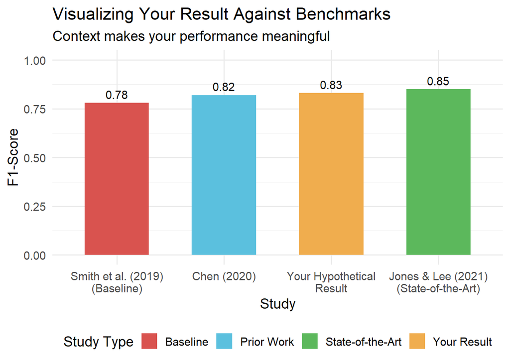

**Reading the chart:** Your hypothetical F1 of 0.83 sits above the baseline (0.78) and prior work (0.82), and is competitive with the SOTA (0.85). Without this comparison, 0.83 has no interpretable meaning.

# Part 3: Establishing Frameworks and Benchmarks via a Literature Search

## How to Conduct a Literature Search

To determine the appropriate frameworks and benchmarks for your study, you must conduct a **literature search**. The goal is to accumulate 10–20 peer-reviewed sources, after which you have enough foundation to begin writing your literature review section.

### Where to Search

| Source | Notes |
| --- | --- |
| **Google Scholar** | Best starting point; broad coverage; shows citation counts |
| **Ask ChatGPT** | Can suggest frameworks and papers — but **always verify the sources exist and say what is claimed** |
| **Reference sections** | Once you find a key paper, mine its reference list for related foundational work |

> **Source quality:** Peer-reviewed journal articles and conference papers are the gold standard. White papers from reputable institutions are acceptable. Blog posts, news articles, and other informal sources are **not** acceptable as primary citations.

### Building Your Search Query

[interactive chart not shown]

## Benchmark Literature Table

As you accumulate sources, track benchmark studies in a structured table:

| Author (Year) | Task / Problem | Method | Metric | Result | Notes |
| --- | --- | --- | --- | --- | --- |
| Smith et al. (2019) | Predicting dropout in MOOCs | Logistic Regression | Accuracy | 78% | Demographic features only. Good baseline. |
| Jones & Lee (2021) | Real-time dropout prediction | Random Forest | F1-Score | 0.85 | Clickstream data. Considered SOTA. |
| Chen (2020) | Identifying at-risk students | SVM | AUC | 0.82 | First two weeks of course only. |

**Synthesis statement template:** *“The current literature shows that for [your task], state-of-the-art models achieve [SOTA metric]. Simpler baseline models achieve [baseline metric]. My goal is to exceed this baseline while [your specific contribution — e.g., using a more interpretable model, applying to a novel population, etc.].”*

# Part 4: The Literature Review

## Purpose of a Literature Review

A literature review is not a summary exercise — it is a **structured argument** that does three specific things:

1. **Relates your work to ongoing discussion in the field** — situating your project within the broader scholarly conversation.
2. **Establishes a framework for the importance of your research question** — demonstrating why your question matters and why it has not been fully answered.
3. **Establishes benchmarks for comparing results and conclusions** — answering “How much better is your model?”, “How much more variance can you explain?”, and “What have you added to what is known?”

## What a Literature Review IS

A well-written literature review is:

- **A logical argument** based on a comprehensive understanding of the state of research on your topic
- **Fully supported by credible sources** — every major claim cites peer-reviewed evidence
- **Explicitly connective** — it shows how your proposed project relates to past work, and very importantly, how your proposed work **extends past studies or addresses their limitations**
- **Organized with logical flow** — it moves coherently from the broad context of your field to your specific research questions

[interactive chart not shown]

## What a Literature Review is NOT

Avoid these common mistakes:

| What students write | What it actually is | Why it fails |
| --- | --- | --- |
| “Smith (2020) found that X. Jones (2021) found that Y. Chen (2022) found that Z.” | An annotated bibliography | No argument, no connection, no synthesis |
| A list of paper summaries with no linking commentary | A data dump | Reader cannot see how it all relates to your project |
| Extensive technical explanation of algorithms you will use | A methods primer | Unless you are developing a new algorithm, briefly justify *why* the method fits — don’t explain how it works |

> A good literature review reads like a coherent essay that happens to have citations, not like a collection of summaries stapled together.

## Citation Management with Zotero

Managing 10–20+ sources manually is error-prone. **Zotero** (https://www.zotero.org/) is the recommended free, open-source citation management tool.

**What Zotero does:**

- Stores full citation metadata (author, year, journal, DOI, etc.)
- Generates formatted citations in APA, MLA, Chicago, and other styles automatically
- Lets you attach PDFs, highlight passages, and keep notes on each source
- Syncs across devices and integrates with Word, Google Docs, and RStudio

HU’s Library has put together resources and guides to help you get started with Zotero.

# Part 5: Organizing Your Literature Review

## Three Methods for Outlining a Literature Review

Before writing, you need a plan. Three proven methods for organizing a literature review are:

### Method 1: Literature Maps

A **literature map** is a diagram that links important concepts and clusters your sources around those concepts. It is the most visual approach and is excellent for seeing the structure of a large body of literature at a glance.

[interactive chart not shown]

Many templates and examples for literature maps are available online. Search for *“literature map examples template”* to find formats that match your project’s complexity.

### Method 2: Subheadings

Essentially a literature map formatted as a **bulleted outline**. Each subheading represents a major concept or theme, and sources are listed under the subheading they belong to.

**Rules of thumb:** * Start from the **broadest concepts and oldest, most foundational methods** and progressively narrow to what is unknown or evolving * No more than **2 subheadings per page** of finished text * At least **4 citations under each subheading**

**Example Topic:** *The influence of Twitter marketing on tech stocks*

**Subheading 1: Twitter Marketing**

- Taecharungroj, V. (2017). Starbucks’ marketing communications strategy on Twitter. *Journal of Marketing Communications, 23*(6), 552–571.
- Leung, X. Y., Bai, B., & Stahura, K. A. (2015). The marketing effectiveness of social media in the hotel industry: A comparison of Facebook and Twitter. *Journal of Hospitality & Tourism Research, 39*(2), 147–169.

**Subheading 2: Tech Industry Marketing**

- Nouri, P., & Ahmady, A. (2018). A taxonomy of nascent entrepreneurs’ marketing decisions in high-tech small businesses. *Journal of Small Business Strategy, 28*(3), 69–79.
- Yang, M., & Gabrielsson, P. (2017). Entrepreneurial marketing of international high-tech business-to-business new ventures. *Industrial Marketing Management, 64*, 147–160.

**Subheading 3: Factors Impacting Tech Stocks**

- Bento, N., Gianfrate, G., & Groppo, S. V. (2019). Do crowdfunding returns reward risk? *Technological Forecasting and Social Change, 141*, 107–116.
- Lee, C. C., Chen, M. P., & Chang, C. H. (2013). Dynamic relationships between industry returns and stock market returns. *The North American Journal of Economics and Finance, 26*, 119–144.

### Method 3: First Sentences

The most rigorous organizational method. Instead of just listing topics, you write **the actual first sentence of each paragraph** in your literature review before writing the full text. Each first sentence is a claim or premise that your supporting citations will back up.

This approach forces you to think through the **logical argument** your literature review is making — every sentence must connect to the next, moving from broad context toward your specific research questions.

**Example Topic:** *Changes in communication styles of political leaders*

> 1. Most scholars and political commentators agree that Donald Trump is unlike any previous US president.
> 2. During his campaign and early presidency, many claimed that Trump’s simplicity and directness were keys to his popularity.
> 3. A second major distinguishing feature of Trump’s language is his self-confidence.
> 4. We build on an extensive research tradition of exploring political leadership traits.
> 5. If conveying simple messages with confidence is a powerful way to persuade voters, it is incumbent on researchers to determine effective ways to measure these dimensions reliably, quickly, and efficiently.
> 6. A common distinction in language is between content words and function words.
> 7. The eight categories of function words capture an underlying psychological dimension known as analytic thinking.
> 8. Past work has validated the use of function words as markers of the analytic thinking dimension, including a study of college admission essays from over 25,000 incoming students.
> 9. The analysis of function words has also been useful in identifying people’s relative status or “clout” in a social hierarchy.
> 10. The computerized text analysis program LIWC was updated in 2015 to include empirically established measures of both analytic thinking and confidence.
> 11. The algorithm developed from Kacewicz et al. is formally referred to as *clout*.
> 12. The purpose of this project was to apply linguistic analyses to large corpora of texts from the American presidency, non-US leaders, legislative bodies, and cultural contexts spanning multiple decades.

Notice how each sentence builds logically on the last — this is a **complete argumentative skeleton** for a literature review before a single full paragraph is written.

# Part 6: Final Guidance on Literature Reviews

[interactive chart not shown]

**Key reminders:**

- Read critically — ask yourself *“Does this source support my argument? Does it contradict it? Does it reveal a gap?”*
- Write short notes or summaries as you read each source — you will not remember the details later
- Keep your research goal visible while writing — every paragraph should connect back to it
- Try to find **multiple citations** supporting your main points — a claim backed by 3–4 sources is much stronger than one backed by 1
- Focus on the **big picture**, not small technical details — unless you are developing a new algorithm, you do not need to extensively explain technical components; briefly discuss why the chosen model makes the most sense for your particular problem

# Bringing It All Together

Your framework, benchmarks, and literature review are not separate deliverables — they are one integrated argument.

[interactive chart not shown]

**Example narrative statement:**

> “My research uses a predictive modeling analytic framework, grounded in an adapted version of Tinto’s Student Integration Model, to predict student dropout in online courses. A literature search revealed that the state-of-the-art F1-Score for this task is 0.85 (Jones & Lee, 2021), using clickstream features, with a baseline of 78% accuracy from simpler demographic models (Smith et al., 2019). My study extends this work by applying theoretically-grounded features tied explicitly to academic and social integration constructs, which prior benchmark studies did not use. By doing so, my model aims to be both predictive and interpretable — addressing a limitation in existing SOTA work that prioritizes performance over explainability.”

# Next Steps & To-Do

- **Action 1:** Identify which type(s) of framework apply to your project (Analytic, Theoretical, Methodological) and locate the foundational paper for your chosen framework.
- **Action 2:** Conduct a literature search on Google Scholar. Collect 10–20 peer-reviewed sources and save them in Zotero.
- **Action 3:** Identify 2–3 benchmark studies and record their task, method, metric, and result in a table.
- **Action 4:** Choose an organizational method (Literature Map, Subheadings, or First Sentences) and draft an outline for your literature review before writing full text.
- **Action 5:** Write a 1-paragraph synthesis statement connecting your research question, your framework, and the key benchmarks you will use for comparison.